# Analysis

This report analyzes ad-hoc requests received by the Data Science team before and after the launch of an AI assistant. The analysis covers January 1 through April 30, 2026. The AI assistant was launched on March 1, 2026. Two metrics are considered: the number of requests received by Data Science and the time required to answer each request. Request volume is analyzed at a daily level, while time to answer is analyzed at the individual level. The purpose of the analysis is to describe how these metrics changed between the two periods.

# Data

The analysis is based on data collected between January 1 and April 30, 2026. The dataset contains information about ad-hoc requests submitted to the Data Science team during this period. Each request represents an individual interaction with the Data Science team. The data contain two main measures. The date on which the request was received and the elapsed time, in minutes, between receiving a request and providing an answer. A separate daily dataset is used to analyze request volume. This dataset contains one observation per calendar day and includes the total number of requests received on that day. The request-level dataset contains one observation per individual request and is used to analyze the distribution of time to answer. The AI assistant was launched on March 1, 2026.

## Dataset structure

The daily dataset contains one observation for each date in the analysis period.

```r
# setup
library(tidyverse)
library(scales)
library(lubridate)

set.seed(123)

launch_date <- as.Date("2026-03-01")

dates <- seq(
  as.Date("2026-01-01"),
  as.Date("2026-04-30"),
  by = "day"
)

# Weekly seasonality
weekday_effect <- c(
  "Monday"    = 1.20,
  "Tuesday"   = 1.25,
  "Wednesday" = 1.20,
  "Thursday"  = 1.15,
  "Friday"    = 0.90,
  "Saturday"  = 0.15,
  "Sunday"    = 0.15
)

mean_weekday_effect <- mean(weekday_effect)

# Daily request data
data_daily <- tibble(
  date = dates
) %>%
  mutate(
    period = if_else(
      date < launch_date,
      "Before AI",
      "After AI"
    ),

    weekday = weekdays(date),

    seasonality = weekday_effect[weekday],

    expected_daily_requests = if_else(
      period == "Before AI",
      120 / 7 *
        seasonality /
        mean_weekday_effect,
      29 / 7 *
        seasonality /
        mean_weekday_effect
    ),

    requests = rpois(
      n(),
      expected_daily_requests
    )
  )

# Individual request data
data_requests <- data_daily %>%
  select(
    date,
    period,
    requests
  ) %>%
  uncount(
    requests,
    .id = "request_number"
  ) %>%
  group_by(period) %>%
  mutate(
    raw_time_to_answer = case_when(

      period == "Before AI" ~
        exp(
          rnorm(
            n(),
            mean = log(1252),
            sd = 1.15
          )
        ),

      period == "After AI" ~
        exp(
          rnorm(
            n(),
            mean = log(35),
            sd = 0.48
          )
        )
    ),

    target_median = if_else(
      period == "Before AI",
      1252,
      35
    ),

    time_to_answer_minutes =
      raw_time_to_answer *
      target_median /
      median(raw_time_to_answer)
  ) %>%
  ungroup() %>%
  mutate(
    time_to_answer_minutes =
      round(time_to_answer_minutes, 1),

    request_id = row_number()
  ) %>%
  select(
    request_id,
    date,
    period,
    time_to_answer_minutes
  )

summary(data_daily)
```

```
      date               period            weekday           seasonality
 Min.   :2026-01-01   Length:120         Length:120         Min.   :0.1500
 1st Qu.:2026-01-30   Class :character   Class :character   1st Qu.:0.1500
 Median :2026-03-01   Mode  :character   Mode  :character   Median :1.1500
 Mean   :2026-03-01                                         Mean   :0.8596
 3rd Qu.:2026-03-31                                         3rd Qu.:1.2000
 Max.   :2026-04-30                                         Max.   :1.2500
 expected_daily_requests    requests
 Min.   : 0.725          Min.   : 0.00
 1st Qu.: 3.000          1st Qu.: 3.00
 Median : 5.800          Median : 6.00
 Mean   :10.499          Mean   :10.53
 3rd Qu.:23.000          3rd Qu.:20.00
 Max.   :25.000          Max.   :36.00
```

## Missing values

Missing values were checked for all variables used in the analysis.

```r
data_requests %>%
  summarise(
    across(
      everything(),
      ~ sum(is.na(.))
    )
  )
```

```
# A tibble: 1 × 4
  request_id  date period time_to_answer_minutes
       <int> <int>  <int>                  <int>
1          0     0      0                      0
```

There are no missing values in the variables used for the analysis.

# Analysis

## Daily request volume

The first analysis looks at the number of Data Science requests received each day.

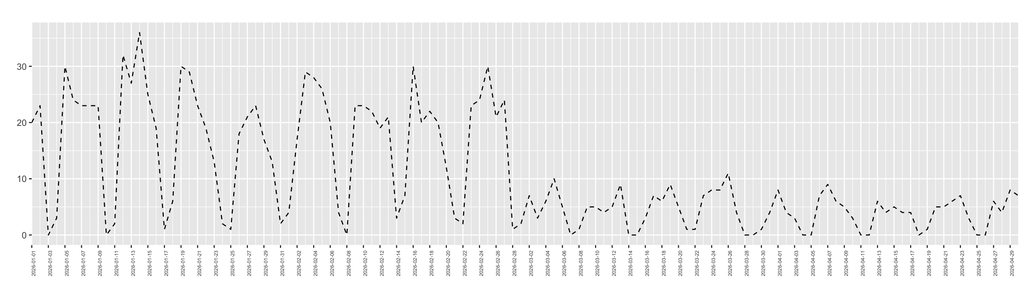

```r
ggplot(
  data_daily,
  aes(
    x = date,
    y = requests
  )
) +
  geom_line(
    linewidth = 0.5,
    lty = 'dashed'
  ) +
  scale_x_date(
    date_breaks = "2 days",
    expand = c(0, 0)
  ) +
  labs(
    title = "",
    x = "",
    y = ""
  ) +
  theme(
    axis.text.x = element_text(
      angle = 90,
      hjust = 1,
      size = 5
    ),
    axis.title = element_text(
      size = 9
    ),
    plot.title = element_text(
      size = 12
    )
  )
```

The daily series in figure 1, shows considerable variation from one day to another. There is also a visible weekly pattern. Request activity is higher during working days and substantially lower during weekends. The level of the series appears to be higher before the launch and lower after the launch. Before March 1, daily request volume is frequently in the range of approximately 15 to 25 requests. After March 1, daily request volume is generally much lower. The daily chart therefore suggests that request volume changed following the launch.

## Time to answer

### Distribution of time to answer

The response-time distribution can be visualized using histograms.

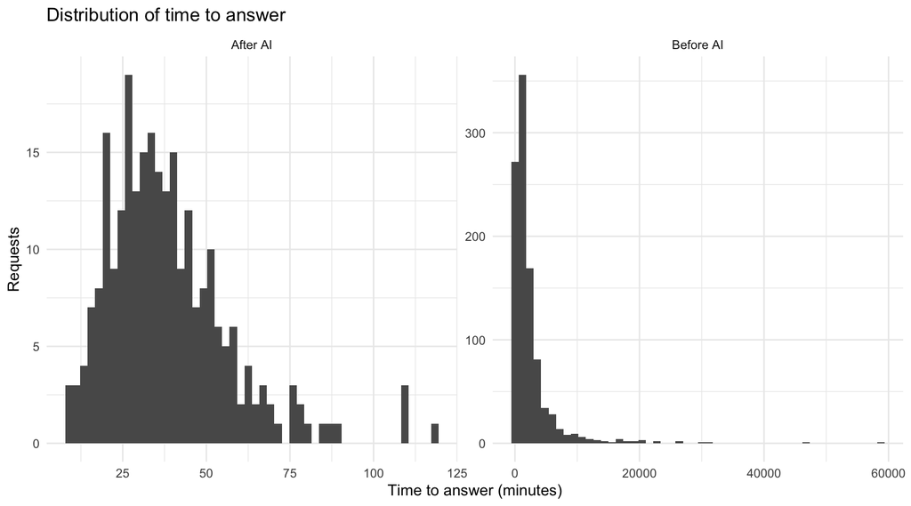

```r
ggplot(
  data_requests,
  aes(
    x = time_to_answer_minutes
  )
) +
  geom_histogram(
    bins = 50
  ) +
  facet_wrap(
    ~ period,
    scales = "free"
  ) +
  labs(
    title = "Distribution of time to answer",
    x = "Time to answer (minutes)",
    y = "Requests"
  ) +
  theme_minimal()
```

The pre-launch distribution is strongly right-skewed. A large proportion of requests require many hundreds of minutes before receiving an answer. There is also a long right tail. Some requests take substantially longer than the median, extending into multiple days. This type of distribution makes the mean difficult to interpret as a measure of a typical request. For example, a small number of very long-running requests can have a large effect on the arithmetic mean. The median is less affected by these extreme observations and therefore provides a useful measure of the typical response time. The post-launch distribution is concentrated much closer to the lower end of the scale. Most requests are answered within a relatively short amount of time.

# Results

The analysis shows substantial differences in both request volume and time to answer between the pre-launch and post-launch periods. Daily request volume decreases after launch and the time to answer also changes substantially. The post-launch distribution is considerably more concentrated around shorter response times than the pre-launch distribution. These results describe an important change in both the volume of requests reaching Data Science and the time required to answer those requests.

*This report is a demonstration example prepared for the posit::conf(2026) by Paula LC.*

**Let’s connect! 👋** Paula LC | Lead Data Scientist | Product Analytics | linkedin.com/in/paulalc